# Project2_STA108_Markdown

Cynthia

2/27/2020

## PART 1: Multiple linear regression I

6.28: Refer to the CDI data set in Appendix C.2. You have been asked to evaluate two alternative models for predicting the number of active physicians (Y) (V8) in a CDI. Proposed model I includes as predictor variables total population (X1) (V5), land area (X2) (V4), and total personal income (X3) (V16). Proposed model II includes as predictor variables population density (X1, total population divided by land area) (V5/V4), percent of population greater than 64 years old (X2) (V7), and total personal income (X3) (V16).

1. Prepare a stem-and-leaf plot for each of the predictor variables. What noteworthy information is provided by your plots?

```
##
##   The decimal point is 6 digit(s) to the right of the |
##
##   0 | 11111111111111111111111111111111111111111111111111111111111111111111+254
##   0 | 55555555555555555555555566666666666666777777777777777777778888888888
##   1 | 000000122233333444
##   1 | 55699
##   2 | 1134
##   2 | 58
##   3 |
##   3 |
##   4 |
##   4 |
##   5 | 1
##   5 |
##   6 |
##   6 |
##   7 |
##   7 |
##   8 |
##   8 | 9
```

```
##
##   The decimal point is 3 digit(s) to the right of the |
##
##    0 | 00001111111111112222222222222222222233333333333333333333333333444444+252
##    1 | 00000000000000011111111111111222222222223333334444555666677778889999
##    2 | 0001111466778
##    3 | 3344688
##    4 | 00122368
##    5 | 45
##    6 | 023
##    7 | 29
##    8 | 11
##    9 | 22
##   10 |
##   11 |
##   12 |
##   13 |
##   14 |
##   15 |
##   16 |
##   17 |
##   18 |
##   19 |
##   20 | 1
```

```
##
##   The decimal point is 4 digit(s) to the right of the |
##
##    0 | 11111111111112222222222222222222222222222222222222222222222222222222+263
##    1 | 000000000000111111111222223333344444445555555567788888888999
##    2 | 001111233344477788899
##    3 | 0255678899
##    4 | 19
##    5 | 59
##    6 |
##    7 |
##    8 |
##    9 |
##   10 |
##   11 | 1
##   12 |
##   13 |
##   14 |
##   15 |
##   16 |
##   17 |
##   18 | 4
```

```
##
##   The decimal point is 3 digit(s) to the right of the |
##
##    0 | 00000000000000001111111111111111111111111111111111111111111111111111+321
##    2 | 00001112233456700111145
##    4 | 05884
##    6 | 2464
##    8 | 19
##   10 | 378
##   12 |
##   14 | 4
##   16 |
##   18 |
##   20 |
##   22 |
##   24 |
##   26 |
##   28 |
##   30 |
##   32 | 4
```

```
##
##   The decimal point is at the |
##
##    2 | 0
##    4 | 47890389
##    6 | 1123455677990134566678899
##    8 | 00112222233334444555666777778888899990002222333333444444445555666677
##   10 | 00011111122222222223333334444445555555666666667777777888888888899999+36
##   12 | 00000000111112222333333333344445555555666666777777777888899900000000+36
##   14 | 000011111112233344444555677889000000111122223455667778
##   16 | 12556699901122345
##   18 | 06778
##   20 | 070
##   22 | 018828
##   24 | 47
##   26 | 055
##   28 | 1
##   30 | 7
##   32 | 138
```

```
##
##   The decimal point is 4 digit(s) to the right of the |
##
##    0 | 11111111111112222222222222222222222222222222222222222222222222222222+263
##    1 | 000000000000111111111222223333344444445555555567788888888999
##    2 | 001111233344477788899
##    3 | 0255678899
##    4 | 19
##    5 | 59
##    6 |
##    7 |
##    8 |
##    9 |
##   10 |
##   11 | 1
##   12 |
##   13 |
##   14 |
##   15 |
##   16 |
##   17 |
##   18 | 4
```

2. Obtain the scatter plot matrix and correlation matrix for each proposed model. Summarize the information provided.

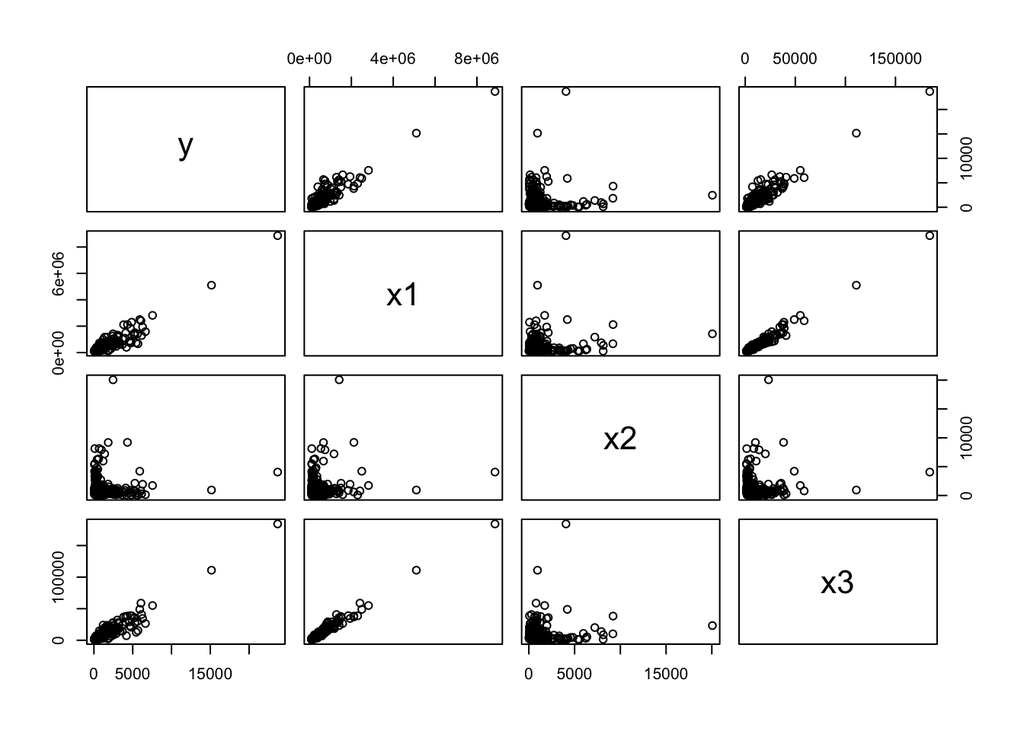

```
##             y        x1         x2        x3
## y  1.00000000 0.9402486 0.07807466 0.9481106
## x1 0.94024859 1.0000000 0.17308335 0.9867476
## x2 0.07807466 0.1730834 1.00000000 0.1270743
## x3 0.94811057 0.9867476 0.12707426 1.0000000
```

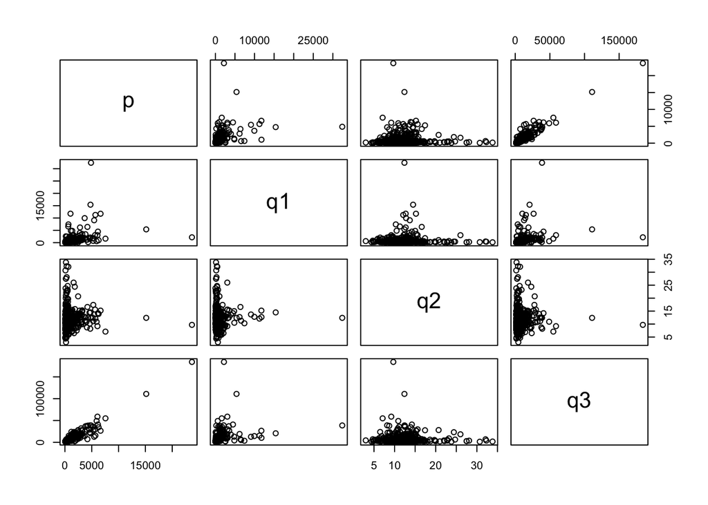

```
##              p         q1          q2          q3
## p   1.00000000 0.40643863 -0.00312863  0.94811057
## q1  0.40643863 1.00000000  0.02918445  0.31620475
## q2 -0.00312863 0.02918445  1.00000000 -0.02273315
## q3  0.94811057 0.31620475 -0.02273315  1.00000000
```

3. For each proposed model, fit the first-order regression model (6.5) with three predictor variables.

```
##
## Call:
## lm(formula = y ~ x1 + x2 + x3, data = data)
##
## Coefficients:
## (Intercept)           x1           x2           x3
##  -1.332e+01    8.366e-04   -6.552e-02    9.413e-02
```

```
##
## Call:
## lm(formula = p ~ q1 + q2 + q3, data = p_data)
##
## Coefficients:
## (Intercept)           q1           q2           q3
##  -170.57422      0.09616      6.33984      0.12657
```

4. Calculate R^2 for each model. Is one model clearly preferable in terms of this measure?

```
## [1] 0.9026432
```

```
## [1] 0.9117491
```

5. For each model, obtain the residuals and plot them against Yhat, each of the three predictor variables, and each of the two-factor interaction terms. Also prepare a normal probability plot for each of the two fitted models. Interpret your plots and state your findings. Is one model clearly preferable in terms of appropriateness?

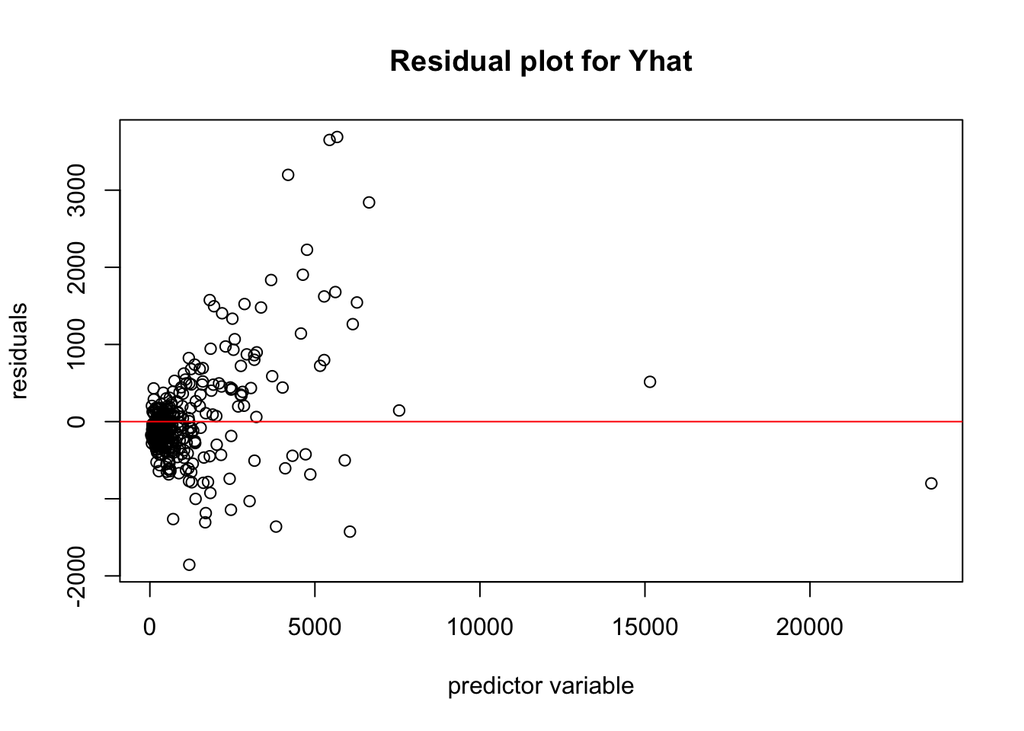

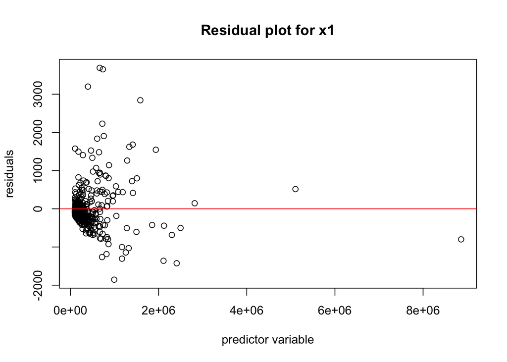

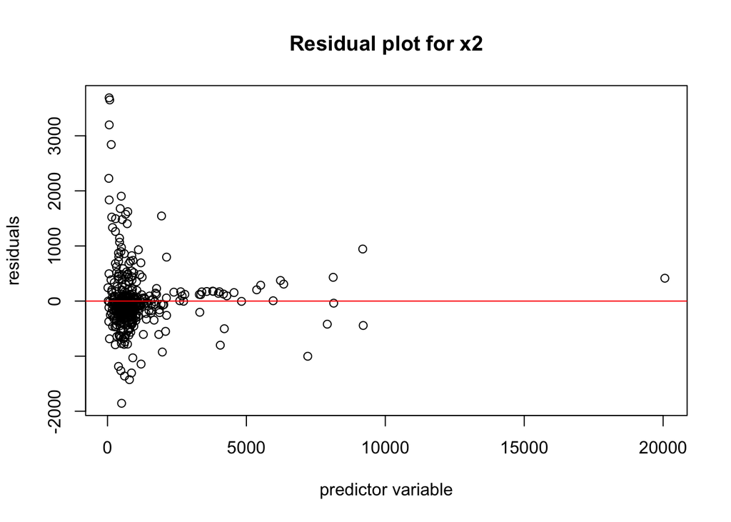

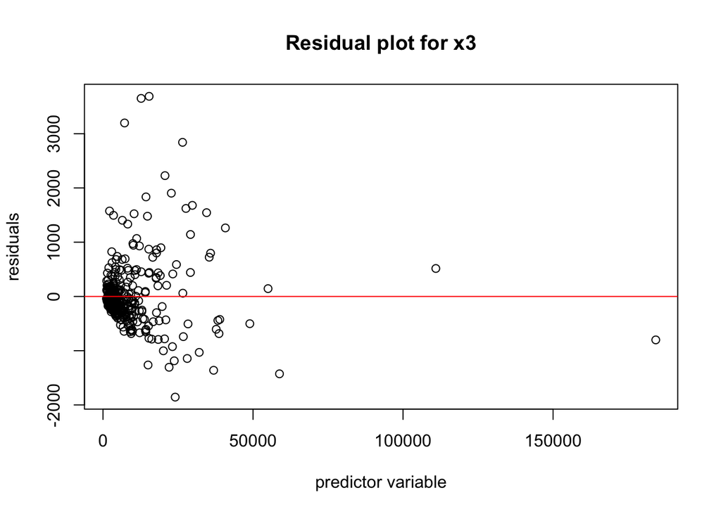

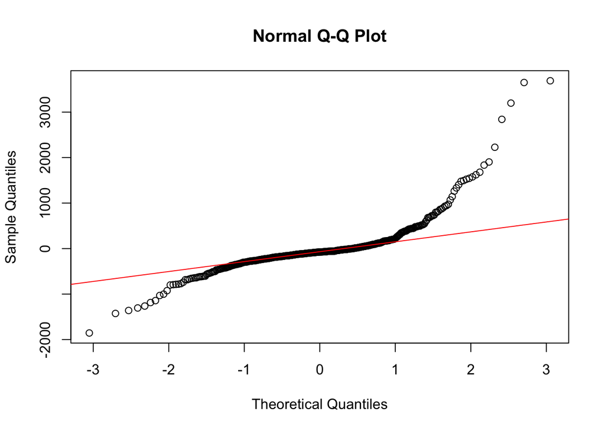

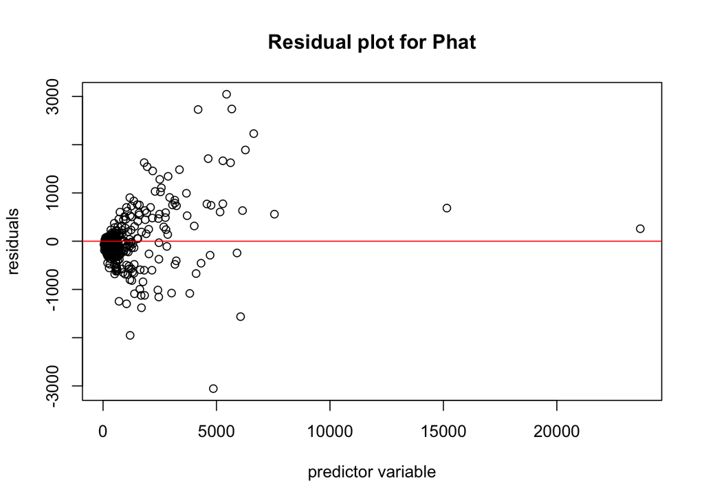

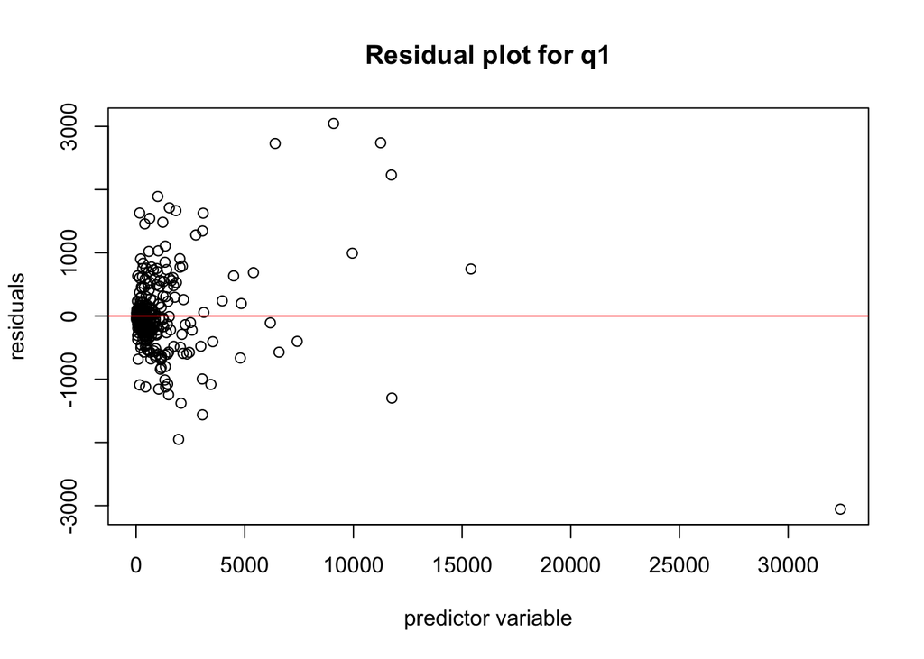

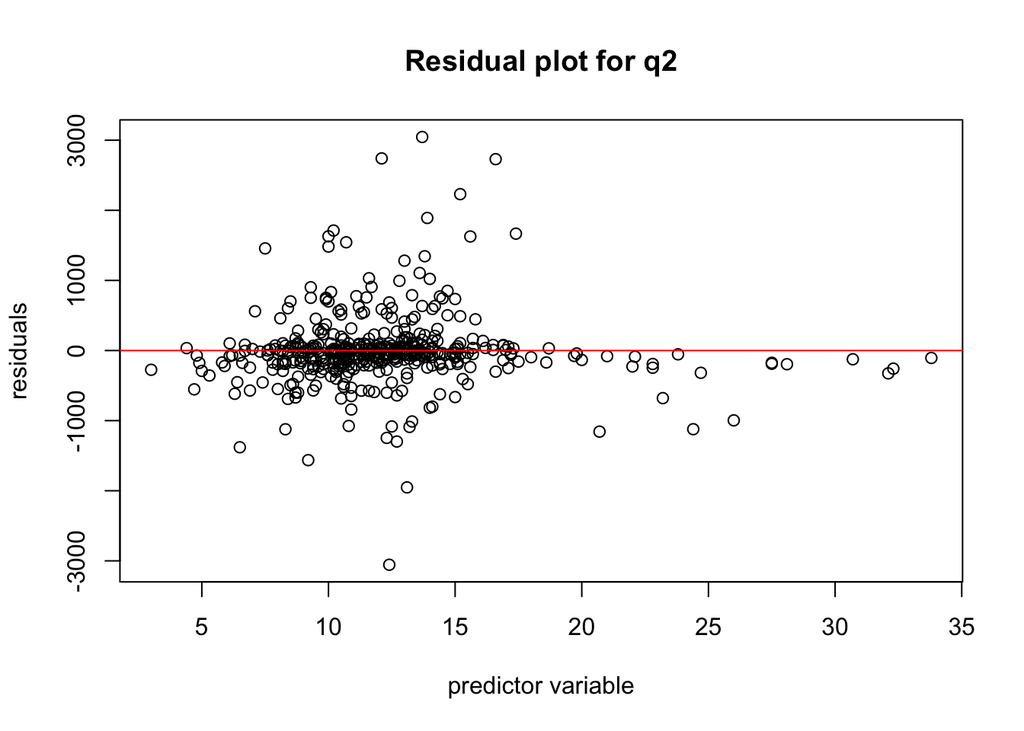

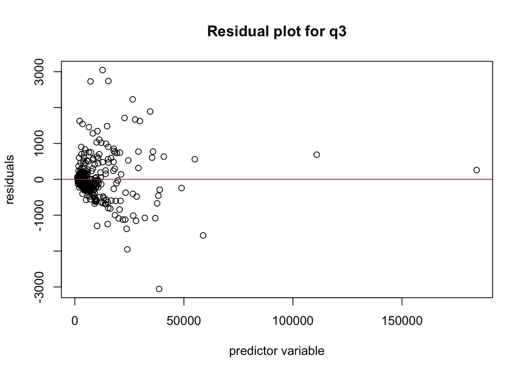

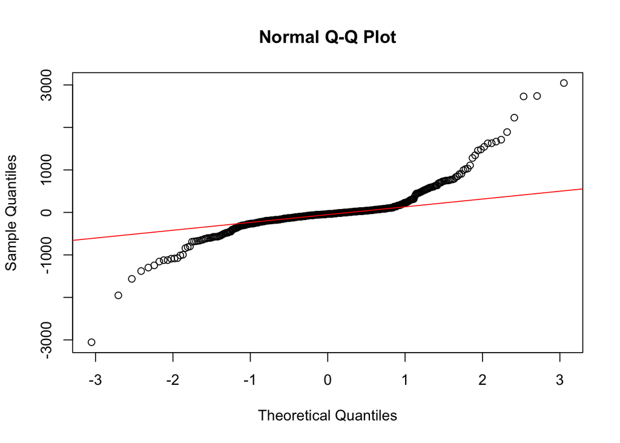

6. Now expand both models proposed above by adding all possible two-factor interactions. Note that, for a model with X1, X2, X3 as the predictors, the two-factor interactions are X1X2, X1X3, X2X3. Repeat part d for the two expanded models.

```
## [1] 0.9063789
```

```
## [1] 0.9230238
```

## PART 2: Multiple linear regression II

7.37: Refer to the CDI data set in Appendix C2. For predicting the number of active physicians (Y) (V8) in a county, it has been decided to include total population (X1) (V5) and total personal income (X2) (V16) as predictor variables. The question now is whether an additional predictor variable would be helpful in the model and, if so, which variable would be most helpful. Assume that a first-order multiple regression model is appropriate.

1.Take out variable X6, that is, you will not consider the total serious crimes (X6) as a predictor in this project. Make the corresponding changes in parts a–c.

1. For each of the following variables, calculate the coefficent of partial determination given that X1 and X2 are included in the model: land area (X3) (V4), percent of population 65 or older (X4) (V7), number of hospital beds (X5) (V9).

```
## [1] 0.02882495
```

```
## [1] 0.003842367
```

```
## [1] 0.5538182
```

2. On the basis of the results in part (a), which of the four additional predictor variables is best? Is the extra sum of squares associated with this variable larger than those for the other three variables?

```
## [1] 4063370
```

```
## [1] 541647.3
```

```
## [1] 78070132
```

3. Using the F* test statistic, test whether or not the variable determined to be best in part (b) is helpful in the regression model when X1 and X2 are included in the model; use alpha = .01. State the alternatives, decision rule, and conclusion. Would the F test statistics for the other three potential predictor variables be as large as the one here? Discuss.

```
## Analysis of Variance Table
##
## Model 1: y ~ x1 + x2
## Model 2: y ~ x1 + x2 + x5
##   Res.Df       RSS Df Sum of Sq      F    Pr(>F)
## 1    437 140967081
## 2    436  62896949  1  78070132 541.18 < 2.2e-16 ***
## ---
## Signif. codes:  0 '***' 0.001 '**' 0.01 '*' 0.05 '.' 0.1 ' ' 1
```

```
## [1] 541.1801
```

```
## [1] 2.00936e-78
```

4. Compute three additional coefficients of partial determination: R2Y,X3,X4|X1,X2, R2Y,X3,X5|X1,X2, and R2Y,X4,X5|X1,X2. Which pair of predictors is relatively more important than other pairs? Use the F test to find out whether adding the best pair to the model is helpful given that X1, X2 are already included.

```
## [1] 0.03314181
```

```
## [1] 0.5558232
```

```
## [1] 0.5642756
```

```
## Analysis of Variance Table
##
## Model 1: y ~ x1 + x2
## Model 2: y ~ x1 + x2 + x4 + x5
##   Res.Df       RSS Df Sum of Sq      F    Pr(>F)
## 1    437 140967081
## 2    435  61422794  2  79544288 281.67 < 2.2e-16 ***
## ---
## Signif. codes:  0 '***' 0.001 '**' 0.01 '*' 0.05 '.' 0.1 ' ' 1
```

```
## [1] 281.6688
```

```
## [1] 3.377372e-79
```

## Code Appendix

```r
knitr::opts_chunk$set(echo = TRUE)
CDI <- read.table('~/Desktop/CDI.txt', header = FALSE)
#Proposed model I
stem(CDI$V5) #total population (X1)
#The stem-and-leaf plot is not symmetric but is right-skewed, with the highest frequency around 0.

stem(CDI$V4) #land area (X2)
#The stem-and-leaf plot is not symmetric but is right-skewed, with the highest frequency around 0 and an outlier.

stem(CDI$V16) #total personal income (X3)
#The stem-and-leaf plot is not symmetric but is right-skewed, with the highest frequency around 0 and some outliers.

# -------

#Proposed model II
stem(CDI$V5 / CDI$V4) #population density (X1)
#The stem-and-leaf plot is not symmetric but is extremely right-skewed, with the highest frequency around 0 and some outliers.

stem(CDI$V7) #percent of population greater than 64 years old (X2)
#The stem-and-leaf plot is approximately symmetric around 10/12.

stem(CDI$V16) #total personal income (X3)
#The stem-and-leaf plot is not symmetric but is right-skewed, with the highest frequency around 0 and some outliers.
#Proposed model I
data = CDI[c(8,5,4,16)]
colnames(data) = c("y","x1","x2", "x3")
pairs(data)
cor(data)
#Based on the scatter plot matrix and correlation matrix, there seems to be a positive relationship between Y (number of active physicians) and X1 (total population) as the scatter plot matrix appears to be approx linear and with the correlation matrix at .9402; between X1 (total population) and X3 (total personal income) as the scatter plot matrix appears to be approx linear and with the correlation matrix at .9867; between Y (number of active physicians) and X3 (total population) as the scatter plot matrix appears to be approx linear and with the correlation matrix at .9481. There doesn't seem to be clear positive relationships between any of the other variable combinations.

#Proposed model II

#p_data = CDI[c(8,cbind(8,5/4,CDI(,7,16)),7,16)] #NEED TO CHECK - shall go to OH
#colnames(p_data) = c("p","q1","q2","q3")
#pairs(p_data)
#cor(p_data)

p_data = CDI[,c(7,16)]
colnames(p_data) = c("q2", "q3")
q1 = CDI$V5/CDI$V4
p = CDI$V8
p_data = cbind(p, q1, p_data)
pairs(p_data)
cor(p_data)

#Based on the scatter plot matrix and correlation matrix, there seems to be a positive relationship between P (number of active physicians) and q3 (total personal income) as the scatter plot matrix appears to be approx linear and with the correlation matrix at .9481. There doesn't seem to be clear positive relationships between any of the other variable combinations.
#Proposed model I
lm(formula = y ~ x1 + x2 + x3, data=data)
#Yhat = .0008355x1 - 0.06552x2 + 0.09413x3 - 13.32

#Proposed model II #don't think this is right
lm(formula = p ~ q1 + q2 + q3, data=p_data)
#Phat = -.3848q1 + 8.2451q2 + 0.1296q3 - 0.3848
#Proposed model I
summary(lm(formula = y ~ x1 + x2 + x3, data = data))$r.squared
#R^2 = 0.9026432

#Proposed model II
summary(lm(formula = p ~ q1 + q2 + q3, data=p_data))$r.squared
#R^2 = 0.8997595

#Because proposed model I (.9026) is the closest r^2 value to 1.00, it is more preferable than proposed model II (.8997).
#Proposed model I -----

#Yhat
fit = lm(formula = y~x1+x2+x3, data=data)
residuals = fit$residuals
plot(x=CDI$V8, y=residuals, xlab='predictor variable', ylab='residuals', main="Residual plot for Yhat")
abline(h=0, col='red')

#x1
fit = lm(formula = y~x1+x2+x3, data=data)
p_residuals = fit$residuals
plot(x=CDI$V5, y=residuals, xlab='predictor variable', ylab='residuals', main="Residual plot for x1")
abline(h=0, col='red')

#x2
fit = lm(formula = y~x1+x2+x3, data=data)
p_residuals = fit$residuals
plot(x=CDI$V4, y=residuals, xlab='predictor variable', ylab='residuals', main="Residual plot for x2")
abline(h=0, col='red')

#x3
fit = lm(formula = y~x1+x2+x3, data=data)
p_residuals = fit$residuals
plot(x=CDI$V16, y=residuals, xlab='predictor variable', ylab='residuals', main="Residual plot for x3")
abline(h=0, col='red')

#UNFINISHED - don't know how to plot for 2-factor interactions?!!!

#normal qq plot
qqplot = qqnorm(p_residuals)
qqline(residuals, col='red', main="Normal QQ Plot") # theoretical line

#Proposed model II -----

#Yhat
fit = lm(formula = p~q1+q2+q3, data=p_data)
residuals = fit$residuals
plot(x=CDI$V8, y=residuals, xlab='predictor variable', ylab='residuals', main="Residual plot for Phat")
abline(h=0, col='red')

#x1
fit = lm(formula = p~q1+q2+q3, data=p_data)
residuals = fit$residuals
plot(x=(CDI$V5)/(CDI$V4), y=residuals, xlab='predictor variable', ylab='residuals', main="Residual plot for q1")
abline(h=0, col='red')

#x2
fit = lm(formula = p~q1+q2+q3, data=p_data)
residuals = fit$residuals
plot(x=CDI$V7, y=residuals, xlab='predictor variable', ylab='residuals', main="Residual plot for q2")
abline(h=0, col='red')

#x3
fit = lm(formula = p~q1+q2+q3, data=p_data)
residuals = fit$residuals
plot(x=CDI$V16, y=residuals, xlab='predictor variable', ylab='residuals', main="Residual plot for q3")
abline(h=0, col='red')

#UNFINISHED - don't know how to plot for 2-factor interactions?!!!

#normal qq plot
qqplot = qqnorm(residuals)
qqline(residuals, col='red', main="Normal QQ Plot") # theoretical line
#Proposed model I
summary(lm(formula = y ~ (x1*x2) + (x1*x3) + (x2*x3), data = data))$r.squared
#R^2 = 0.9063789

#Proposed model II
summary(lm(formula = p ~ (q1*q2) + (q1*q3) + (q2*q3), data = p_data))$r.squared
#R^2 = 0.9021035
y = CDI$V8
x1 = CDI$V5
x2 = CDI$V16
x3 = CDI$V4
x4 = CDI$V7
x5 = CDI$V9

#land area (X3)
model.before = lm(y~x1+x2, data=CDI)
model.after = lm(y~x1+x2+x3, data=CDI)
SSE.before = sum(model.before$residuals^2)
SSE.after = sum(model.after$residuals^2)
partial.R2 = (SSE.before - SSE.after)/(SSE.before)
partial.R2
#Coefficent of partial determination for land area (X3) is 0.02882495.

#percent of population 65 or older (X4)
model.before = lm(y~x1+x2, data=CDI)
model.after = lm(y~x1+x2+x4, data=CDI)
SSE.before = sum(model.before$residuals^2)
SSE.after = sum(model.after$residuals^2)
partial.R2 = (SSE.before - SSE.after)/(SSE.before)
partial.R2
#Coefficent of partial determination for percent of population 65 or older (X4) is 0.003842367.

#number of hospital beds (X5)
model.before = lm(y~x1+x2, data=CDI)
model.after = lm(y~x1+x2+x5, data=CDI)
SSE.before = sum(model.before$residuals^2)
SSE.after = sum(model.after$residuals^2)
partial.R2 = (SSE.before - SSE.after)/(SSE.before)
partial.R2
#Coefficent of partial determination for number of hospital beds (X5) is 0.5538182.
#land area (X3)
model.before = lm(y~x1+x2, data=CDI)
model.after = lm(y~x1+x2+x3, data=CDI)
SSE.before = sum(model.before$residuals^2)
SSE.after = sum(model.after$residuals^2)
extra.SS = SSE.before - SSE.after
extra.SS
#Extra sum of squares is 4063370.

#percent of population 65 or older (X4)
model.before = lm(y~x1+x2, data=CDI)
model.after = lm(y~x1+x2+x4, data=CDI)
SSE.before = sum(model.before$residuals^2)
SSE.after = sum(model.after$residuals^2)
extra.SS = SSE.before - SSE.after
extra.SS
#Extra sum of squares is 541647.3.

#number of hospital beds (X5)
model.before = lm(y~x1+x2, data=CDI)
model.after = lm(y~x1+x2+x5, data=CDI)
SSE.before = sum(model.before$residuals^2)
SSE.after = sum(model.after$residuals^2)
extra.SS = SSE.before - SSE.after
extra.SS
#Extra sum of squares is 78070132.

#As the coefficent of partial determination (R^2) becomes near to 1, the variable Y values come close to the line of regression. Thus, number of hospital beds (X5) is best, as R^2 is closest to 1. In addition, the extra sum of squares associated with this variable (78070132) is larger than the variables X1 (4063370) and X2 (541647.3).
#H0: β5 = 0
#H1: B5 != 0
#alpha: .01

reduced.model = lm(y~x1+x2, data=CDI)
full.model = lm(y~x1+x2+x5, data=CDI)
anova(reduced.model, full.model)

SSE.reduced = sum(reduced.model$residuals^2)
SSE.full = sum(full.model$residuals^2)

df.reduced = nrow(CDI) - 3
df.full = nrow(CDI) - 4
F.statistic = ( (SSE.reduced-SSE.full)/(df.reduced-df.full) ) / (SSE.full/df.full)
F.statistic
#F* = 541.1801
pf(F.statistic, df.reduced-df.full, df.full, lower.tail = FALSE)
#pvalue = 2.00936e-78

#UNFINISHED

model.before = lm(y~x1+x2, data=CDI)
SSE.before = sum(model.before$residuals^2)

#R2Y,X3,X4|X1,X2
model.after = lm(y~x1+x2+x3+x4, data=CDI)
SSE.after = sum(model.after$residuals^2)
partial.R2 = (SSE.before - SSE.after)/(SSE.before)
partial.R2
#Coefficent of partial determination for R2Y,X3,X4|X1,X2 is 0.03314181.

#R2Y,X3,X5|X1,X2
model.after = lm(y~x1+x2+x3+x5, data=CDI)
SSE.after = sum(model.after$residuals^2)
partial.R2 = (SSE.before - SSE.after)/(SSE.before)
partial.R2
#Coefficent of partial determination for R2Y,X3,X5|X1,X2 is 0.5558232.

#R2Y,X4,X5|X1,X2
model.after = lm(y~x1+x2+x4+x5, data=CDI)
SSE.after = sum(model.after$residuals^2)
partial.R2 = (SSE.before - SSE.after)/(SSE.before)
partial.R2
#Coefficent of partial determination for R2Y,X4,X5|X1,X2 is 0.5642756.

#R^2 of Y,X3,X5|X1,X2 (0.5558232) and Y,X4,X5|X1,X2 (0.5642756) are quite close and seem to be more important than Y,X3,X4|X1,X2 (0.03314181). However, Y,X4,X5|X1,X2 (0.5642756) is greater than Y,X3,X5|X1,X2 (0.5558232), and so we can safely assume that Y,X4,X5|X1,X2 is the most important of the three and is the pair (X4, X5) we can test through the F test to see whether it is helpful given that X1 and X2 are already included.

#F TEST -----

#H0: β4 = B5 = 0
#H1: B5 != 0 or B5 != 0

reduced.model = lm(y~x1+x2, data=CDI)
full.model = lm(y~x1+x2+x4+x5, data=CDI)
anova(reduced.model, full.model)

SSE.reduced = sum(reduced.model$residuals^2)
SSE.full = sum(full.model$residuals^2)

df.reduced = nrow(CDI) - 3
df.full = nrow(CDI) - 5
F.statistic = ( (SSE.reduced-SSE.full)/(df.reduced-df.full) ) / (SSE.full/df.full)
F.statistic
#F* = 281.6688
pf(F.statistic, df.reduced-df.full, df.full, lower.tail = FALSE)
#pvalue = 3.377372e-79

#UNFINISHED
```